# Solutions to tidying exercises

Ina Bornkessel-Schlesewsky

## Exercises from R4DS

For a more comprehensive set of solutions to the R4DS exercises, see [this website by Jeffrey Arnold](https://jrnold.github.io/r4ds-exercise-solutions/). There is also [this study guide by Bryan Shalloway](https://brshallo.github.io/r4ds_solutions/).

### 12.2 Exercise 2: computing the rate from table2 and table4

Compute the rate for table2 first:

```r
# Note that this solution calculates the rate by adding it into table2 in its current format
cases_per_year <- table2 %>%
  filter(type =="cases")

population_per_year <- table2 %>%
  filter(type =="population")

rate <- cases_per_year$count / population_per_year$count * 10000
country <- rep(unique(table2$country), each=2)
year <- rep(unique(table2$year), 3)
type <- rep("rate",6)

interim_table <- tibble(country,year,type,rate) %>%
  rename(count = rate)

newtable2 <- table2 %>%
  bind_rows(interim_table) %>%
  arrange(country,year,type)

newtable2
```

```
## # A tibble: 18 x 4
##    country      year type         count
##    <chr>       <int> <chr>        <dbl>
##  1 Afghanistan  1999 cases      7.45e+2
##  2 Afghanistan  1999 population 2.00e+7
##  3 Afghanistan  1999 rate       3.73e-1
##  4 Afghanistan  2000 cases      2.67e+3
##  5 Afghanistan  2000 population 2.06e+7
##  6 Afghanistan  2000 rate       1.29e+0
##  7 Brazil       1999 cases      3.77e+4
##  8 Brazil       1999 population 1.72e+8
##  9 Brazil       1999 rate       2.19e+0
## 10 Brazil       2000 cases      8.05e+4
## 11 Brazil       2000 population 1.75e+8
## 12 Brazil       2000 rate       4.61e+0
## 13 China        1999 cases      2.12e+5
## 14 China        1999 population 1.27e+9
## 15 China        1999 rate       1.67e+0
## 16 China        2000 cases      2.14e+5
## 17 China        2000 population 1.28e+9
## 18 China        2000 rate       1.67e+0
```

```r
# A different (and slightly simpler) approach could have been to just create a new version of table2 with just the rate

newtable2_rate_only <- tibble(country,year,rate)

newtable2_rate_only
```

```
## # A tibble: 6 x 3
##   country      year  rate
##   <chr>       <int> <dbl>
## 1 Afghanistan  1999 0.373
## 2 Afghanistan  2000 1.29
## 3 Brazil       1999 2.19
## 4 Brazil       2000 4.61
## 5 China        1999 1.67
## 6 China        2000 1.67
```

Now compute the rate for table4a (which includes the cases) and table4b (which includes the population):

```r
pop1999 <- table4b$`1999`
pop2000 <- table4b$`2000`

newtable4 <- table4a %>%
  mutate(`1999` = `1999` / pop1999 * 10000,
         `2000` = `2000` / pop2000 * 10000)
```

### 12.2 Exercise 3: plot cases over time from table2

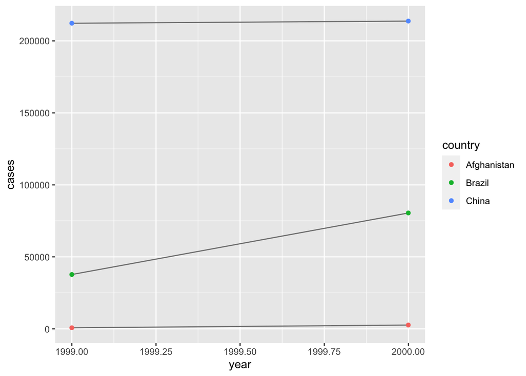

```r
ggplot(filter(table2,type =="cases"), aes(year, count)) +
  geom_line(aes(group = country), colour = "grey50") +
  geom_point(aes(colour = country)) +
  ylab("cases")
```

Note that the following syntax also works:

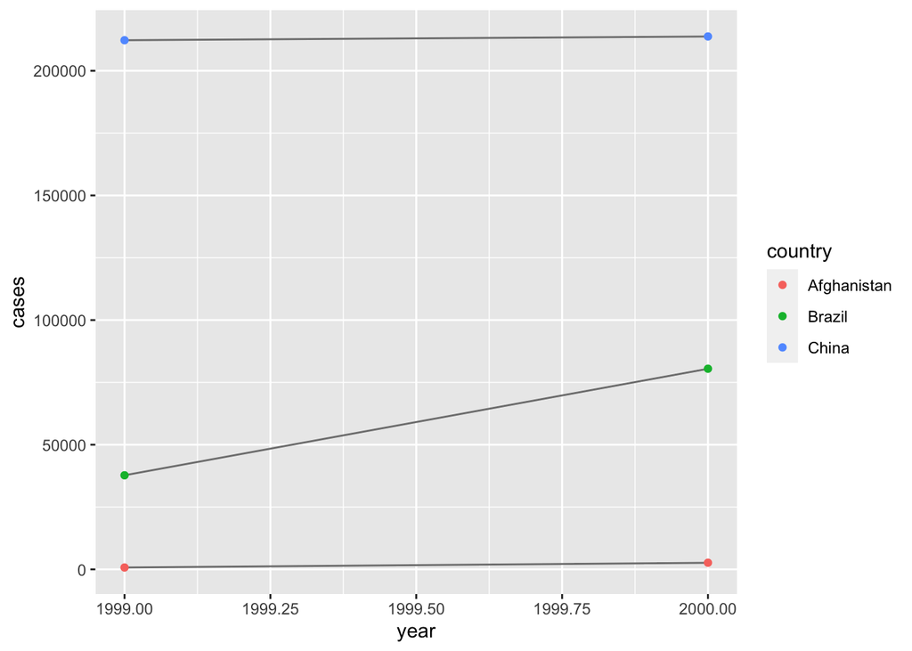

```r
table2 %>%
  filter(type == "cases") %>%
  ggplot(aes(year, count)) +
    geom_line(aes(group = country), colour = "grey50") +
    geom_point(aes(colour = country)) +
    ylab("cases")
```

### 12.3 Exercise 1

Why are `pivot_longer()` and `pivot_wider()` not perfectly symmetrical? Carefully consider the following example (Hint: look at the variable types and think about column names.):

```r
stocks <- tibble(
  year   = c(2015, 2015, 2016, 2016),
  half  = c(   1,    2,     1,    2),
  return = c(1.88, 0.59, 0.92, 0.17)
)
stocks %>%
  pivot_wider(names_from = year, values_from = return) %>%
  pivot_longer(`2015`:`2016`, names_to = "year", values_to = "return")
```

```
## # A tibble: 4 x 3
##    half year  return
##   <dbl> <chr>  <dbl>
## 1     1 2015    1.88
## 2     1 2016    0.92
## 3     2 2015    0.59
## 4     2 2016    0.17
```

*Year is a character column when reconverted back to longer format due to the values having been column names after conversion to wider format. We can convert back to numeric using `mutate` and `as.double` **or** directly in `pivot_longer` using `names_transform`.*

```r
stocks %>%
  pivot_wider(names_from = year, values_from = return) %>%
  pivot_longer(`2015`:`2016`, names_to = "year", values_to = "return") %>%
  mutate(year = as.double(year))
```

```
## # A tibble: 4 x 3
##    half  year return
##   <dbl> <dbl>  <dbl>
## 1     1  2015   1.88
## 2     1  2016   0.92
## 3     2  2015   0.59
## 4     2  2016   0.17
```

```r
stocks %>%
  pivot_wider(names_from = year, values_from = return) %>%
  pivot_longer(`2015`:`2016`, names_to = "year", values_to = "return", names_transform = list(year = as.double))
```

```
## # A tibble: 4 x 3
##    half  year return
##   <dbl> <dbl>  <dbl>
## 1     1  2015   1.88
## 2     1  2016   0.92
## 3     2  2015   0.59
## 4     2  2016   0.17
```

pivot_longer() has a names_ptypes argument, e.g. names_ptypes = list(year = double()). What does it do?

```r
#stocks %>%
#  pivot_wider(names_from = year, values_from = return) %>%
#  pivot_longer(`2015`:`2016`, names_to = "year", values_to = "return", names_ptypes = list(year = double()))
```

*`names_ptypes` can be used to check whether the newly created columns are of the expected type. If this is not the case, an error occurs. The problem can be resolved using `names_transform` as shown above. Note the difference in syntax: `names_ptypes` uses `double()`, which tests for a double, while `names_transform` uses `as.double`, which specifies the function to use for conversion.*

### 12.3 Exercise 2

Why does this code fail? Note that it is commented out so that the Rmd will knit. Uncomment it to see the error.

```r
# table4a %>%
#  pivot_longer(c(1999, 2000), names_to = "year", values_to = "cases")
```

*The column names are not enclosed in quotes (i.e. backticks ``)*

### 12.3 Exercise 3

What would happen if you widen this table? Why? How could you add a new column to uniquely identify each value?

```r
people <- tribble(
  ~name,             ~names,  ~values,
  #-----------------|--------|------
  "Phillip Woods",   "age",       45,
  "Phillip Woods",   "height",   186,
  "Phillip Woods",   "age",       50,
  "Jessica Cordero", "age",       37,
  "Jessica Cordero", "height",   156
)

people %>%
  pivot_wider(names_from = names, values_from = values)
```

```
## Warning: Values are not uniquely identified; output will contain list-cols.
## * Use `values_fn = list` to suppress this warning.
## * Use `values_fn = length` to identify where the duplicates arise
## * Use `values_fn = {summary_fun}` to summarise duplicates
```

```
## # A tibble: 2 x 3
##   name            age       height
##   <chr>           <list>    <list>
## 1 Phillip Woods   <dbl [2]> <dbl [1]>
## 2 Jessica Cordero <dbl [1]> <dbl [1]>
```

*I’m not 100% sure what was intended here. However, my take on this question is that you need to be aware of when there are duplicate values – this is why `pivot_wider` produces a warning when you try to widen the data frame. It also gives you some potential solutions (try these out for yourself to see how they work!). For example, you can use `values_fn` in conjunction with `mean` to summarise the duplicates using the mean. An option to “add a new column to uniquely identify each value” would be to change the label of the second entry for age to something unique (e.g. age2). Which option you choose depends on the data and your understanding of what is going on with the duplicates.*

```r
people %>%
  pivot_wider(names_from = names, values_from = values, values_fn = {mean})
```

```
## # A tibble: 2 x 3
##   name              age height
##   <chr>           <dbl>  <dbl>
## 1 Phillip Woods    47.5    186
## 2 Jessica Cordero  37      156
```

```r
people2 <- people
people2[3,2] <- "age2"

people2 %>%
  pivot_wider(names_from = names, values_from = values)
```

```
## # A tibble: 2 x 4
##   name              age height  age2
##   <chr>           <dbl>  <dbl> <dbl>
## 1 Phillip Woods      45    186    50
## 2 Jessica Cordero    37    156    NA
```

### 12.3 Exercise 4

Tidy the simple tibble below. Do you need to make it wider or longer? What are the variables?

```r
preg <- tribble(
  ~pregnant, ~male, ~female,
  "yes",     NA,    10,
  "no",      20,    12
)

preg %>%
  pivot_longer(male:female, names_to = "sex", values_to = "count")
```

```
## # A tibble: 4 x 3
##   pregnant sex    count
##   <chr>    <chr>  <dbl>
## 1 yes      male      NA
## 2 yes      female    10
## 3 no       male      20
## 4 no       female    12
```